[figure not shown]

November 12, 2026

# What’s data science?

## North Star Academy Summit Program

November 2026

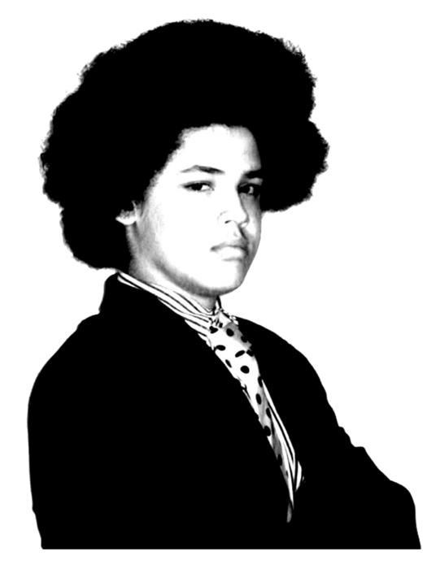

# Agenda

- 1Intro & Why Calm
- 2What might data science look like?
- 3My Goals for You
- 4Your Stories and Your Goals
- 5Questions

Part 1

# Who am I; how did I get here?

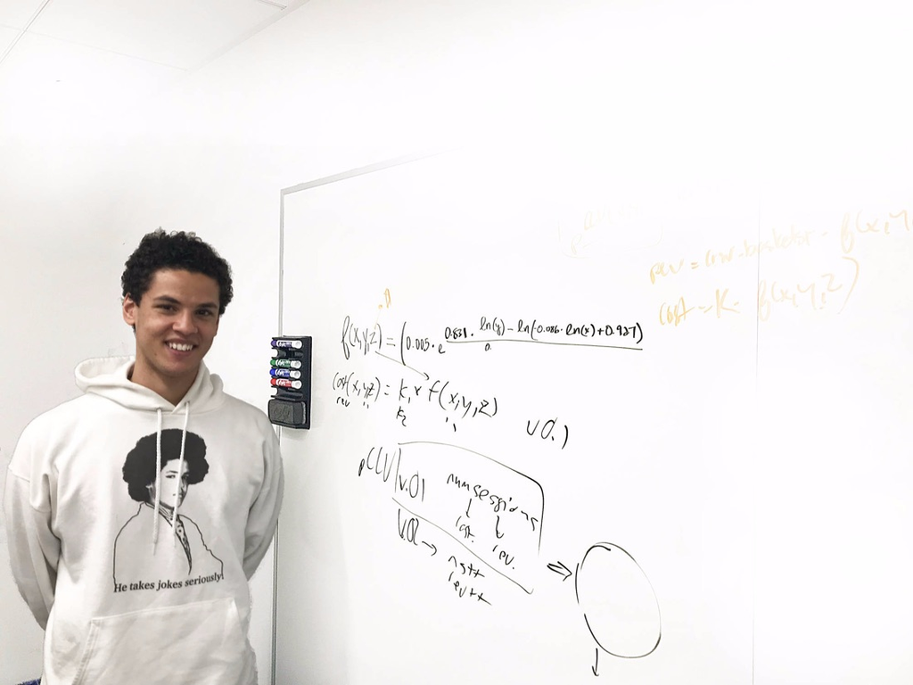

**Morgan Stanley**Started my analytics career in finance, working on debt modeling

**Meta & Google**Learned data science best practices

**HeadsUp**A machine learning startup

**Hayward Data Science**My company: consulting & app-developing for the last 2 years

Fried chicken

J Dilla

Giraffes (plural)

Stand-up comedy

Pro bono lawyer

# Why Calm?

[figure not shown]

# Quote from LeBron

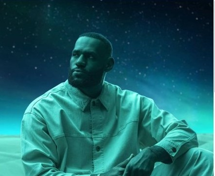

“We all face pressure, and we all have big moments. And especially with social media, people are always watching. We’re living in a time when everyone's got fans and doubters. The one thing that's true about all human beings is that we’ve all got goals and dreams and we all got doubts and fears. Everyone's got insecurities that they might take a big shot and miss.

My thing is basketball, and right now I'm trying to help a team reclaim its legacy as a championship franchise. You’re dealing with your own thing right now. Maybe it’s an exam to get into college. Maybe you’re starting a new company. Maybe you want to upload that first song to SoundCloud. Maybe you’re inspired to be a stand-up comedian, and there’s an open mic night in your city. You're just not sure you got what it takes to show up in front of a bunch of strangers and grab that mic.

Well if nobody's told you yet, I’ll tell you: you’ve got it. We just need to breathe and be in a moment.

Whatever it is, we’re all gonna face it. Whatever it is, we all need to stay calm and focus when we get there. That's what it's about. At the end of the day, those big moments: you can either own them or they own you. Just take a deep breath, and take that shot, with a ton of focus and confidence. And you need to trust yourself. Trust that you can do it. Believe that you're the person who makes that shot. It might sound a little corny, I know, but I’ve learned it’s true. The reason I am where I am: because people along the way helped me believe in a bigger vision of who I could be or what I could do.”

—LeBron James, Calm

Part 2

# What might data science look like?

# Data science is a loop

Ask a  
question

Get the  
data

Clean it

Explore  
& model

Tell the  
story

Then the story leads to a **better question**, and you go around again.

Tools change (Sheets, Python, AI). The loop doesn’t.

# Where it shows up

Finance

### Will this loan get paid back?

Debt models at Morgan Stanley: numbers that decide where billions of dollars go.

Tech

### Who’s about to cancel?

Every dot is a customer. Red dots left. Can you spot where they cluster?

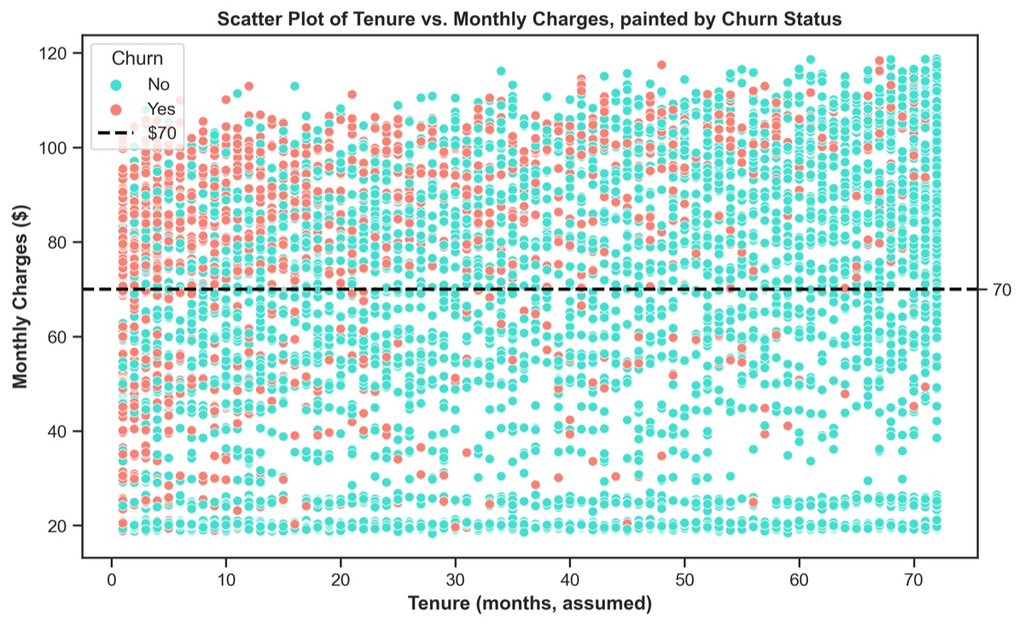

Apps

### Sound Recipe

An app I built and run. Data tells me what people actually use.

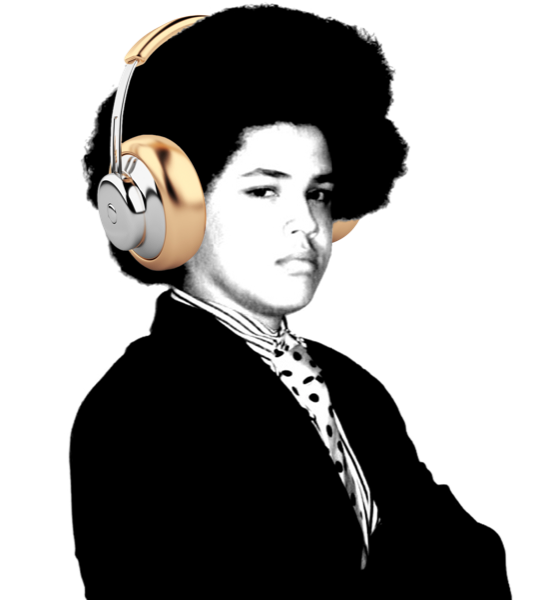

# Our dataset this year: me

**2,001**days on a bathroom scale

**2017 → 2024**seven years

**1**person (hi)

Rule #1

# A real question we’ll answer

Which day of the week am I **heaviest**?

Part 3

# Goals

Have fun

Get a peek at the world of data science

Have me as a resource for the future

Have a foundation to learn more, if you choose to

# How we get there

**Google Sheets**Now → Dec 3  
Formulas on real data

**Python in Colab**Starts Jan 14  
Code does the math

**AI (Gemini)**Winter  
Redo it with AI, then check it

**Your presentation**April 15  
Tell your story with data

Part 4

# Your Stories and Your Goals

# What you want out of this class

# In your words

Anonymous · from your goals Form

Coding has always been so fascinating to me, and soon I will be able to understand that language!

I want to learn more about data, technology, and how they can help people.

I’ve realized how much I appreciate the art of technology.

Code something functional from scratch with Python.

# Questions you want to answer with data

Anonymous · from your goals Form

How do political conflicts and events affect the stock market?

How does technology help doctors find diseases earlier?

What was the change in global temperature from last year to this year?

What percentage of cars are lemons in each state?

What would life be like without data science?

What is the purpose of life?

Part 5

# Questions

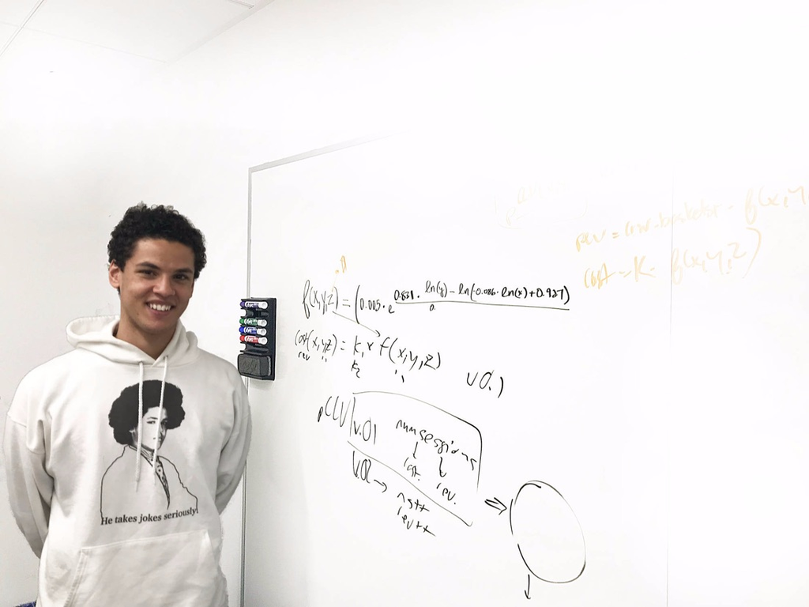

**Hayward Data Science**

haywarddatascience.com

george@haywarddatascience.com

**Build the word cloud**

Paste only the **answer** columns from the goals Form (not names or emails). Only word counts are kept, in this browser. Common words, emails, numbers and offensive words are dropped. During the talk, click any word to hide it.